# **Machine Learning - LAB3 - Bayesian Methods**

**Field of Study: Computer Science - Data Science**  
**Author: Bartłomiej Jamiołkowski**

```python
from sklearn.datasets import load_breast_cancer, fetch_20newsgroups, load_iris
from sklearn.model_selection import train_test_split, GridSearchCV
from sklearn.metrics import accuracy_score, f1_score, precision_score
from sklearn.ensemble import RandomForestClassifier
from sklearn.preprocessing import StandardScaler, power_transform, LabelEncoder, PowerTransformer
from sklearn.decomposition import PCA, KernelPCA
from sklearn.feature_extraction.text import CountVectorizer
from sklearn.feature_selection import SequentialFeatureSelector
from sklearn.naive_bayes import GaussianNB, BernoulliNB
from sklearn.impute import SimpleImputer
from sklearn.pipeline import Pipeline
from imblearn.over_sampling import RandomOverSampler
from sklearn.compose import ColumnTransformer
from collections import Counter
import matplotlib.pyplot as plt
from mpl_toolkits.axes_grid1 import ImageGrid
from scipy import stats
import pandas as pd
import numpy as np
import warnings
warnings.filterwarnings('ignore')
```

### 1. Gaussian Naive Bayes Classifier

#### 1.1 Implement a Naive Bayes Classifier for continuous data assuming a normal probability distribution for each feature separately. In the implementation you can use the standard scikit-learn interface for predictive models - fit() and predict() methods.

$$ p(x_i | C_k) = \frac{1}{\sqrt{2 \pi \sigma_{i, C_k}^2}} \exp \left( -\frac{(x_i - \mu_{i, C_k})^2}{2 \sigma_{i, C_k}^2} \right) $$

#### 1.2 Determine the mean and standard deviation of the continuous feature xi for a given class Ck, and then calculate the posterior probabilities using Bayes' Theorem and the likelihood given by Eq. 6

Implementing Gaussian Naive Bayes Classifier from scratch.

```python
class GaussianNaiveBayes:
    def __init__(self):
        self.classes = None
        self.class_priors = None
        self.means = None
        self.std_devs = None

    def fit(self, X: np.ndarray, y: np.ndarray) -> None:
        self.classes = np.unique(y)
        self.class_priors = np.zeros(len(self.classes))
        self.means = np.zeros((len(self.classes), X.shape[1]))
        self.std_devs = np.zeros((len(self.classes), X.shape[1]))

        for class_idx, unique_class in enumerate(self.classes):
            X_class = X[y == unique_class, :]
            self.class_priors[class_idx] = float(X_class.shape[0] / X.shape[0])
            self.means[class_idx] = np.mean(X_class, axis=0)
            self.std_devs[class_idx] = np.std(X_class, axis=0, ddof=1)

    def calc_gaussian_prob(self, class_idx: int, x: np.ndarray) -> np.ndarray:
        mean = self.means[class_idx]
        std_dev = self.std_devs[class_idx]
        exponent = np.exp(- (x - mean) ** 2 / (2 * std_dev ** 2))
        denominator = np.sqrt(2 * np.pi * std_dev ** 2)
        return exponent / denominator

    def predict(self, X: np.ndarray) -> np.ndarray:
        predictions = np.zeros(X.shape[0], dtype=int)

        for idx, x in enumerate(X):
            conditional = np.zeros(len(self.classes))

            for class_idx, _ in enumerate(self.classes):
                conditional[class_idx] = np.log(self.calc_gaussian_prob(class_idx, x)).sum()

            posteriors = np.log(self.class_priors) + conditional
            predictions[idx] = self.classes[np.argmax(posteriors)]

        return predictions
```

#### 1.3 Test your own implementation of the classifier on the Iris dataset (4 features). Randomly split the dataset into training and test parts by a ratio of 0.6, 0.4. Repeat the experiment 20 times and measure the average values:

#### - f1-score

#### Compare the results obtained using your own implementation and the results obtained using scikit-learn GaussianNB.

Loading Iris dataset. Separating features and target.

```python
iris_data = load_iris()
X_iris, y_iris = iris_data.data, iris_data.target
```

Creating function for experiments in tasks 1.3 and 1.4.

```python
def run_experiment(X: np.ndarray, y: np.ndarray, model, test_size: float, repeats: int = 20, processor=None):
    metrics = {
        'accuracy': [],
        'f1_score': [],
        'precision': []
    }

    for _ in range(repeats):
        X_train, X_test, y_train, y_test = train_test_split(X, y, test_size=test_size, random_state=None)

        if processor is not None:

            if isinstance(processor, (PCA, KernelPCA)):
                scaler = StandardScaler()
                X_train = scaler.fit_transform(X_train)
                X_test = scaler.transform(X_test)

            X_train = processor.fit_transform(X_train)
            X_test = processor.transform(X_test)

        model.fit(X_train, y_train)
        y_pred = model.predict(X_test)

        metrics['accuracy'].append(accuracy_score(y_test, y_pred))
        metrics['f1_score'].append(f1_score(y_test, y_pred, average='weighted'))
        metrics['precision'].append(precision_score(y_test, y_pred, average='weighted'))

    mean_metrics = {metric: np.mean(values) for metric, values in metrics.items()}

    return mean_metrics
```

Comparing the results obtained using own implementation and the results obtained using scikit-learn GaussianNB.

```python
gnb_scratch = GaussianNaiveBayes()

mean_results_gnb_scratch = run_experiment(X_iris, y_iris, gnb_scratch, test_size=0.4, repeats=20)
print(f'GaussianNaiveBayes: {mean_results_gnb_scratch}')

gnb_sklearn = GaussianNB()

mean_results_gnb_sklearn = run_experiment(X_iris, y_iris, gnb_sklearn, test_size=0.4, repeats=20)
print(f'GaussianNB: {mean_results_gnb_sklearn}')
```

```
GaussianNaiveBayes: {'accuracy': 0.9524999999999997, 'f1_score': 0.9525822641742554, 'precision': 0.9553377043151358}
GaussianNB: {'accuracy': 0.9558333333333332, 'f1_score': 0.9557406252811533, 'precision': 0.95826271180281}
```

The obtained results indicate that the GaussianNB model is better at correctly classifying instances in the dataset than the GaussianNaiveBayes implementation from scratch. All metrics: accuracy, F1 score, and precision are in this case higher for the GaussianNB model.

#### - scaling (StandardScaler)

#### - dimension reduction (PCA and Kernel PCA, choose the best value for n components and the kernel function on Kernel PCA)

#### - Box-Cox transformation (choose the best value for parameter λ)

#### on the average classification results. Does this type of preprocessing of the dataset impact their improvement? Compare the obtained classification accuracy (Naive Bayes Classifier) with the classification accuracy obtained for random forests (default hyperparameter values) in the same experimental setup. Discuss the obtained results.

In this task, I decided to compare GaussianNB, my implementation of GaussianNaiveBayes and RandomForestClassifier.

Loading Breast Cancer dataset. Separating features and target.

```python
cancer_data = load_breast_cancer()
X_cancer, y_cancer = cancer_data.data, cancer_data.target
```

**Raw data**

First, I am testing and comparing models without any modifications. I am doing this in order to have results to which I can refer later.

```python
gnb_scratch = GaussianNaiveBayes()

mean_results_gnb_scratch = run_experiment(X_cancer, y_cancer, gnb_scratch, test_size=0.3, repeats=20)
print(f'GaussianNaiveBayes: {mean_results_gnb_scratch}')

gnb_sklearn = GaussianNB()

mean_results_gnb_sklearn = run_experiment(X_cancer, y_cancer, gnb_sklearn, test_size=0.3, repeats=20)
print(f'GaussianNB: {mean_results_gnb_sklearn}')

rf = RandomForestClassifier()

mean_results_rf = run_experiment(X_cancer, y_cancer, rf, test_size=0.3, repeats=20)
print(f'RandomForestClassifier: {mean_results_rf}')
```

```
GaussianNaiveBayes: {'accuracy': 0.9263157894736841, 'f1_score': 0.9261837038071633, 'precision': 0.92704198308042}
GaussianNB: {'accuracy': 0.9482456140350874, 'f1_score': 0.9480153344651011, 'precision': 0.9488317848989059}
RandomForestClassifier: {'accuracy': 0.9561403508771928, 'f1_score': 0.9560277837031423, 'precision': 0.9567451033366933}
```

The obtained results indicate that the RandomForestClassifier model is the best at correctly classifying instances in the dataset among the tested models. All its metrics have the highest values. The second model is GaussianNB, as in the previous experiment. The least accurate model among those considered is the GaussianNaiveBayes implementation from scratch.

**Scaling (StandardScaler)**

```python
scaler = StandardScaler()

mean_results_gnb_scratch_scaled = run_experiment(X_cancer, y_cancer, gnb_scratch, test_size=0.3, repeats=20, processor=scaler)
print(f'GaussianNaiveBayes: {mean_results_gnb_scratch_scaled}')

mean_results_gnb_sklearn_scaled = run_experiment(X_cancer, y_cancer, gnb_sklearn, test_size=0.3, repeats=20, processor=scaler)
print(f'GaussianNB: {mean_results_gnb_sklearn_scaled}')

mean_results_rf_scaled = run_experiment(X_cancer, y_cancer, rf, test_size=0.3, repeats=20, processor=scaler)
print(f'RandomForestClassifier: {mean_results_rf_scaled}')
```

```
GaussianNaiveBayes: {'accuracy': 0.9330409356725144, 'f1_score': 0.9329526975081684, 'precision': 0.9334841360210404}
GaussianNB: {'accuracy': 0.9239766081871345, 'f1_score': 0.9237683349247687, 'precision': 0.9244294162062481}
RandomForestClassifier: {'accuracy': 0.9555555555555554, 'f1_score': 0.9554322266051642, 'precision': 0.9559021761807175}
```

**Dimension reduction (PCA)**

In this part of the task, I am supposed to choose the best value for n_components in PCA. There are several methods to determine the optimal number of components. I decided to use a straightforward approach. I will keep enough principal components to explain at least 95% of the variance in the data. I am also scaling data in my experiment function before applying PCA.

```python
pca = PCA(n_components=0.95)

mean_results_gnb_scratch_pca = run_experiment(X_cancer, y_cancer, gnb_scratch, test_size=0.3, repeats=20, processor=pca)
print(f'GaussianNaiveBayes: {mean_results_gnb_scratch_pca}')

mean_results_gnb_sklearn_pca = run_experiment(X_cancer, y_cancer, gnb_sklearn, test_size=0.3, repeats=20, processor=pca)
print(f'GaussianNB: {mean_results_gnb_sklearn_pca}')

mean_results_rf_pca = run_experiment(X_cancer, y_cancer, rf, test_size=0.3, repeats=20, processor=pca)
print(f'RandomForestClassifier: {mean_results_rf_pca}')
```

```
GaussianNaiveBayes: {'accuracy': 0.9154970760233919, 'f1_score': 0.9149055959084859, 'precision': 0.9168262209877787}
GaussianNB: {'accuracy': 0.9093567251461987, 'f1_score': 0.9087279591560321, 'precision': 0.9104381678508757}
RandomForestClassifier: {'accuracy': 0.949707602339181, 'f1_score': 0.9494835547644476, 'precision': 0.9502005516617598}
```

The obtained results indicate that data scaling followed by dimension reduction (PCA) has a negative impact on the classification accuracies of all tested models. I am not surprised by these results, as some information was lost. Nevertheless, the RandomForestClassifier model is the best at correctly classifying instances in the dataset among the tested models.

**Dimension reduction (Kernel PCA)**

In this part of the task, I am supposed to choose the best value for n components and the kernel function on Kernel PCA. Therefore, I am going to use GridSearch in order to find optimal combination of these parameters.

```python
X_cancer_train, X_cancer_test, y_cancer_train, y_cancer_test = train_test_split(X_cancer, y_cancer, test_size=0.3)

pipeline = Pipeline([
    ('kpca', KernelPCA()),
    ('classifier', GaussianNB())
])

grid_search = GridSearchCV(
    pipeline,
    [{
        'kpca__n_components': list(range(1, 31)),
        'kpca__kernel': ['rbf', 'sigmoid', 'linear', 'poly']
    }],
    cv=10,
    scoring='accuracy')

grid_search.fit(X_cancer_train, y_cancer_train)

print(grid_search.best_params_)
print(grid_search.best_score_)
```

```
{'kpca__kernel': 'poly', 'kpca__n_components': 10}
0.9221794871794872
```

```python
kernel_pca = KernelPCA(kernel='poly', n_components=10)

mean_results_gnb_scratch_kpca = run_experiment(X_cancer, y_cancer, gnb_scratch, test_size=0.3, repeats=20, processor=kernel_pca)
print(f'GaussianNaiveBayes: {mean_results_gnb_scratch_kpca}')

mean_results_gnb_sklearn_kpca = run_experiment(X_cancer, y_cancer, gnb_sklearn, test_size=0.3, repeats=20, processor=kernel_pca)
print(f'GaussianNB: {mean_results_gnb_sklearn_kpca}')

mean_results_rf_kpca = run_experiment(X_cancer, y_cancer, rf, test_size=0.3, repeats=20, processor=kernel_pca)
print(f'RandomForestClassifier: {mean_results_rf_kpca}')
```

```
GaussianNaiveBayes: {'accuracy': 0.8812865497076023, 'f1_score': 0.8769827908566086, 'precision': 0.8899116444088634}
GaussianNB: {'accuracy': 0.8754385964912281, 'f1_score': 0.8713141515304752, 'precision': 0.8811342856289082}
RandomForestClassifier: {'accuracy': 0.9549707602339179, 'f1_score': 0.9549179392767154, 'precision': 0.9556684389494026}
```

The obtained results indicate that data scaling followed by dimension reduction (KernelPCA) has a negative impact on the classification accuracies of all tested models. I am not surprised by these results, as some information was lost. Nevertheless, the RandomForestClassifier model is the best at correctly classifying instances in the dataset among the tested models.

**Transformation Box-Cox**

In this part of the task, I am supposed to choose the best value of lambda parameter for Box-Cox transformation. I am going to use PowerTransformer with box-cox method.

```python
X_cancer = X_cancer + 0.1

box_cox = PowerTransformer(method='box-cox', standardize=True)

mean_results_gnb_scratch_boxcox= run_experiment(X_cancer, y_cancer, gnb_scratch, test_size=0.3, repeats=20, processor=box_cox)
print(f'GaussianNaiveBayes: {mean_results_gnb_scratch_boxcox}')

mean_results_gnb_sklearn_boxcox = run_experiment(X_cancer, y_cancer, gnb_sklearn, test_size=0.3, repeats=20, processor=box_cox)
print(f'GaussianNB: {mean_results_gnb_sklearn_boxcox}')

mean_results_rf_boxcox = run_experiment(X_cancer, y_cancer, rf, test_size=0.3, repeats=20, processor=box_cox)
print(f'RandomForestClassifier: {mean_results_rf_boxcox}')
```

```
GaussianNaiveBayes: {'accuracy': 0.9450292397660818, 'f1_score': 0.9448538594636713, 'precision': 0.9457213325170732}
GaussianNB: {'accuracy': 0.9546783625730992, 'f1_score': 0.9545349188817042, 'precision': 0.9549184943558477}
RandomForestClassifier: {'accuracy': 0.9578947368421054, 'f1_score': 0.9578152516437486, 'precision': 0.9583608012734949}
```

The obtained results indicate that data transformation (Box-Cox) has a positive impact on the classification accuracy of all tested models. All these metrics are slightly higher than in the first experiment. Moreover, the results show that the RandomForestClassifier model is the best at correctly classifying instances in the dataset among the tested models, with all its metrics having the highest values.

### 2. Naive Bayes Classifier with Bernoulli Distribution

#### Implement a Naive Bayes Classifier assuming a Bernoulli probability distribution for each binary feature. Use Laplace smoothing to avoid problems related to zeroing the probability of data that did not appear in a given class in the training set. Present a test of the classifier using a selected dataset of short texts (e.g. 20 news groups).

$$ P(x_i | C_k) = \theta_{x_i | C_k}^{x_i} (1 - \theta_{x_i | C_k})^{1 - x_i} $$

Implementing Naive Bayes Classifier with Bernoulli Distribution from scratch.

```python
class BernoulliNaiveBayes:
    def __init__(self):
        self.classes = None
        self.class_priors = None
        self.feature_probs = None

    def fit(self, X: np.ndarray, y: np.ndarray) -> None:
        self.classes = np.unique(y)
        self.class_priors = np.zeros(len(self.classes))
        self.feature_probs = {}

        for class_idx, unique_class in enumerate(self.classes):
            X_class = X[y == unique_class, :]
            self.class_priors[class_idx] = float(X_class.shape[0] / X.shape[0])

            feature_counts = np.sum(X_class, axis=0) + 1  # Laplace smoothing
            total_count = X_class.shape[0] + 2
            self.feature_probs[unique_class] = feature_counts / total_count

    def calc_bernoulli_prob(self, class_idx: int, x: np.ndarray) -> np.ndarray:
        prob = self.feature_probs[self.classes[class_idx]]
        prob = (prob ** x) * ((1 - prob) ** (1 - x))
        return prob

    def predict(self, X: np.ndarray) -> np.ndarray:
        predictions = np.zeros(X.shape[0], dtype=int)

        for idx, x in enumerate(X):
            conditional = np.zeros(len(self.classes))

            for class_idx, _ in enumerate(self.classes):
                conditional[class_idx] = np.sum(np.log(self.calc_bernoulli_prob(class_idx, x)))

            posteriors = np.log(self.class_priors) + conditional
            predictions[idx] = self.classes[np.argmax(posteriors)]

        return predictions
```

Tesing of the classifier using a selected dataset of short texts (e.g. 20 news groups).

Loading 20 news groups dataset. Separating features and target.

```python
newsgroups_data = fetch_20newsgroups(subset='train', categories=['alt.atheism', 'comp.graphics', 'sci.space', 'misc.forsale'])

cv = CountVectorizer(binary=True)
X_newsgroups = cv.fit_transform(newsgroups_data.data).toarray()
y_newsgroups = newsgroups_data.target
```

```python
X_newsgroups_train, X_newsgroups_test, y_newsgroups_train, y_newsgroups_test = train_test_split(X_newsgroups, y_newsgroups, test_size=0.4, random_state=25)

bnb_scratch = BernoulliNaiveBayes()

bnb_scratch.fit(X_newsgroups_train, y_newsgroups_train)
y_newsgroups_pred = bnb_scratch.predict(X_newsgroups_test)

accuracy = accuracy_score(y_newsgroups_test, y_newsgroups_pred)
f1_score = f1_score(y_newsgroups_test, y_newsgroups_pred, average='weighted')
precision = precision_score(y_newsgroups_test, y_newsgroups_pred, average='weighted')

print(f'Accuracy: {accuracy}')
print(f'F1-score: {f1_score}')
print(f'Precision: {precision}')
```

```
Accuracy: 0.8595317725752508
F1-score: 0.8609847400273267
Precision: 0.8762510372956224
```

Obtained results indicate that custom BernoulliNaiveBayes model has quite well performance and effectively distinguishes between different newsgroups.

### 3. Naive Bayes Classifier for Adult Income Dataset

#### Using a 70%, 30% hold-out, examine the baseline accuracy of the NKB classifier for the Adult Income dataset. Print the average classification accuracy and standard deviation for 50 splits (baseline). Then propose several strategies for preprocessing the dataset (handling missing values, NA, . . .), several strategies for feature engineering (nominal feature encoding, scaling, multiple Box-Cox transformations, . . .), and feature selection (Sequential Feature Selection) to improve the classification accuracy (approach 84%). You can use sklearn.pipeline.Pipeline and both library and custom implementations of the NKB classifiers for your implementation.

Loading Adult Income dataset.

```python
adult_income = pd.read_csv('adult.csv')
adult_income_copy = adult_income.copy()
adult_income_copy.head()
```

|  | age | workclass | fnlwgt | education | educational-num | marital-status | occupation | relationship | race | gender | capital-gain | capital-loss | hours-per-week | native-country | income |
| --- | --- | --- | --- | --- | --- | --- | --- | --- | --- | --- | --- | --- | --- | --- | --- |
| 0 | 25 | Private | 226802 | 11th | 7 | Never-married | Machine-op-inspct | Own-child | Black | Male | 0 | 0 | 40 | United-States | <=50K |
| 1 | 38 | Private | 89814 | HS-grad | 9 | Married-civ-spouse | Farming-fishing | Husband | White | Male | 0 | 0 | 50 | United-States | <=50K |
| 2 | 28 | Local-gov | 336951 | Assoc-acdm | 12 | Married-civ-spouse | Protective-serv | Husband | White | Male | 0 | 0 | 40 | United-States | >50K |
| 3 | 44 | Private | 160323 | Some-college | 10 | Married-civ-spouse | Machine-op-inspct | Husband | Black | Male | 7688 | 0 | 40 | United-States | >50K |
| 4 | 18 | ? | 103497 | Some-college | 10 | Never-married | ? | Own-child | White | Female | 0 | 0 | 30 | United-States | <=50K |

Cleaning dataset by removing rows with NaN values.

```python
adult_income_copy = adult_income_copy.replace('?', np.nan).dropna()
```

Separating features and target.

```python
X_adult_income_copy, y_adult_income_copy = adult_income_copy.iloc[:, :14], adult_income_copy.iloc[:, 14]
```

```python
le = LabelEncoder()
y_adult_income_copy_encoded = le.fit_transform(y_adult_income_copy)
X_adult_income_copy_encoded = pd.get_dummies(X_adult_income_copy).values.astype(int)
```

Examining the baseline accuracy of the NKB classifier for the Adult Income dataset. Printing the average classification accuracy and standard deviation for 50 splits (baseline).

```python
def run_experiment(X, y, model, test_size, repeats, processor=None):
    accuracies = []

    for _ in range(repeats):
        X_train, X_test, y_train, y_test = train_test_split(X, y, test_size=test_size, random_state=None)

        if isinstance(processor, StandardScaler):
            X_train = processor.fit_transform(X_train)
            X_test = processor.transform(X_test)
        elif isinstance(processor, SequentialFeatureSelector):
            processor.fit(X_train, y_train)
            selected_features = processor.get_support(indices=True)
            X_train = X_train[:, selected_features]
            X_test = X_test[:, selected_features]

        model.fit(X_train, y_train)
        y_pred = model.predict(X_test)
        accuracies.append(accuracy_score(y_test, y_pred))

    results = {'accuracy': np.mean(accuracies), 'std_dev': np.std(accuracies)}

    return results
```

```python
bnb = BernoulliNB()
results_bnb= run_experiment(X_adult_income_copy_encoded, y_adult_income_copy_encoded, bnb, test_size=0.3, repeats=50)
print(results_bnb)
```

```
{'accuracy': 0.7559652097000072, 'std_dev': 0.003781045362377298}
```

Obtained baseline model accuracy (75.60%) and low standard deviation indicate that a performance of the model is acceptable. However it can be improved.

#### Proposing several strategies for preprocessing the dataset

**Handling missing values by replacing them with mean for numeric features or most frequent values for categorical features.**

```python
adult_income_copy = adult_income.copy()
```

```python
adult_income_copy_numeric_cols = adult_income_copy.select_dtypes(include=['float64', 'int64']).columns
adult_income_copy_categorical_cols = adult_income_copy.select_dtypes(include=['object']).columns
```

```python
numerical_imputer = SimpleImputer(strategy='mean')
adult_income_copy[adult_income_copy_numeric_cols] = numerical_imputer.fit_transform(adult_income_copy[adult_income_copy_numeric_cols])

categorical_imputer = SimpleImputer(strategy='most_frequent')
adult_income_copy[adult_income_copy_categorical_cols] = categorical_imputer.fit_transform(adult_income_copy[adult_income_copy_categorical_cols])
```

```python
X_adult_income_copy, y_adult_income_copy = adult_income_copy.iloc[:, :14], adult_income_copy.iloc[:, 14]
```

```python
le = LabelEncoder()
y_adult_income_copy_encoded = le.fit_transform(y_adult_income_copy)
X_adult_income_copy_encoded = pd.get_dummies(X_adult_income_copy).values.astype(int)
```

```python
bnb = BernoulliNB()
results_bnb = run_experiment(X_adult_income_copy_encoded , y_adult_income_copy_encoded, bnb, test_size=0.3, repeats=50)
print(results_bnb)
```

```
{'accuracy': 0.7608039309356446, 'std_dev': 0.0038057549871239427}
```

Obtained results indicate that replacing missing values resultet in model improvement. However, accuracy is still far from desired 84%.

**Using RandomOverSampler solve problem of class imbalance in dataset.**

Checking if dataset is imbalanced.

```python
Counter(y_adult_income_copy_encoded)
```

```
Counter({0: 37155, 1: 11687})
```

Obtained results indicate that dataset is imbalanced. Therefore i am going to apply RandomOverSampler solve problem of class imbalance in dataset.

```python
adult_income_copy = adult_income.copy()
adult_income_copy = adult_income_copy.replace('?', np.nan).dropna()
X_adult_income_copy, y_adult_income_copy = adult_income_copy.iloc[:, :14], adult_income_copy.iloc[:, 14]

le = LabelEncoder()
y_adult_income_copy_encoded = le.fit_transform(y_adult_income_copy)
X_adult_income_copy_encoded = pd.get_dummies(X_adult_income_copy).values.astype(int)
```

```python
ros = RandomOverSampler(random_state=25)

X_adult_income_copy_resampled, y_adult_income_copy_resampled = ros.fit_resample(X_adult_income_copy_encoded, y_adult_income_copy_encoded)
```

```python
bnb = BernoulliNB()
results_bnb = run_experiment(X_adult_income_copy_resampled, y_adult_income_copy_resampled, bnb, test_size=0.3, repeats=50)
print(results_bnb)
```

```
{'accuracy': 0.771258758390906, 'std_dev': 0.0024618043841834036}
```

Obtained results indicate that in this case rebalancing dataset resulted in increased accuracy.

#### Proposing several strategies for feature engineering

**Scaling (StandardScaler)**

```python
adult_income_copy = adult_income.copy()
adult_income_copy = adult_income_copy.replace('?', np.nan).dropna()
X_adult_income_copy, y_adult_income_copy = adult_income_copy.iloc[:, :14], adult_income_copy.iloc[:, 14]

le = LabelEncoder()
y_adult_income_copy_encoded = le.fit_transform(y_adult_income_copy)
X_adult_income_copy_encoded = pd.get_dummies(X_adult_income_copy).values.astype(int)
```

```python
scaler = StandardScaler()
bnb = BernoulliNB()
results_bnb = run_experiment(X_adult_income_copy_encoded , y_adult_income_copy_encoded , bnb, test_size=0.3, repeats=50, processor=scaler)
print(results_bnb)
```

```
{'accuracy': 0.7797626593941182, 'std_dev': 0.003346288885729426}
```

Obtained results indicate that application of scaling significantly increased model's accuracy.

**Logarithmic transformations**

```python
adult_income_copy = adult_income.copy()
adult_income_copy = adult_income_copy.replace('?', np.nan).dropna()
X_adult_income_copy, y_adult_income_copy = adult_income_copy.iloc[:, :14], adult_income_copy.iloc[:, 14]

le = LabelEncoder()
y_adult_income_copy_encoded = le.fit_transform(y_adult_income_copy)
X_adult_income_copy_encoded = pd.get_dummies(X_adult_income_copy).values.astype(int)
```

```python
y_adult_income_copy_log = np.log(y_adult_income_copy_encoded + 0.1)
X_adult_income_copy_log = np.log(X_adult_income_copy_encoded + 0.1)

bnb = BernoulliNB()
results_bnb = run_experiment(X_adult_income_copy_encoded, y_adult_income_copy_encoded, bnb, test_size=0.3, repeats=50)
print(results_bnb)
```

```
{'accuracy': 0.7568806663226948, 'std_dev': 0.0037700605520775508}
```

#### Proposing strategies for feature selection

**Using Sequential Feature Selection to select the most important features.**

```python
adult_income_copy = adult_income.copy()
adult_income_copy = adult_income_copy.replace('?', np.nan).dropna()
X_adult_income_copy, y_adult_income_copy = adult_income_copy.iloc[:, :14], adult_income_copy.iloc[:, 14]

le = LabelEncoder()
y_adult_income_copy_encoded = le.fit_transform(y_adult_income_copy)
X_adult_income_copy_encoded = pd.get_dummies(X_adult_income_copy).values.astype(int)
```

```python
bnb = BernoulliNB()

sfs = SequentialFeatureSelector(bnb, n_features_to_select=5, direction='forward', cv=3)
results_bnb = run_experiment(X_adult_income_copy_encoded , y_adult_income_copy_encoded , bnb, test_size=0.3, repeats=50, processor=sfs)
print(results_bnb)
```

```
{'accuracy': 0.8202624014151985, 'std_dev': 0.0023887050081961886}
```

Obtained accuracy is the highest among all test results. It is the closes accuracy to 84%. It means taht Sequential Feature Selection has significant impact on model's accuracy.

## 4. Bayesian Linear Regression Online *

#### 4.1 Implement Bayesian Linear Regression online using the following helper class

Implementing Bayesian Linear Regression from scratch.

```python
class BayesianLinearRegression:

    def __init__(self, n_features, alpha, beta):
        self.n_features = n_features
        self.alpha = alpha
        self.beta = beta
        self.mean = np.zeros(n_features)
        self.cov = np.identity(n_features) * alpha
        self.cov_inv = np.linalg.inv(self.cov)

    def learn(self, x, y):
        self.cov_inv += self.beta * np.outer(x, x)
        self.cov = np.linalg.inv(self.cov_inv)
        self.mean = self.cov @ (self.cov_inv @ self.mean + self.beta * y * x)

        return self

    def predict(self, x):
        y_pred_mean = x @ self.mean
        y_pred_var = 1 / self.beta + x @ self.cov @ x.T

        return stats.norm(loc=y_pred_mean, scale=y_pred_var ** .5)

    @property
    def weights_dist(self):
        return stats.multivariate_normal(mean=self.mean, cov=self.cov)
```

#### 4.2 Generate an artificial dataset in 2D (10 points from the interval [−1, 1]) according to the formula t = −0.2 + 0.6x + ϵ, where ϵ is a Gaussian noise with mean 0 and standard deviation 0.2.

```python
weights = np.array([-0.2, 0.6])

def sample(n):
    for _ in range(n):
        x = np.array([1, np.random.uniform(-1, 1)])
        y = -0.2 + 0.6 * x[1] + np.random.normal(0, .2)  # Use the exact formula here
        yield x, y
```

#### 4.3 Visualize the next steps of the online Bayesian Linear Regression (β = 25, α = 2) for the first 7 points from the dataset. For each step i:

#### a) Draw (contourf()) the bivariate prior distribution for the weights w1 and w2 of the model y = w1 + w2x

#### b) Draw (contourf()) the bivariate posterior distribution for the weights w1 and w2

#### c) Draw the predictive distribution (predictive mean, predictive interval), the line t = −0.2 + 0.6x and the points used to build the predictive distribution.

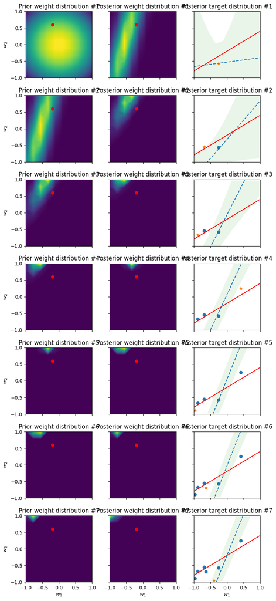

```python
np.random.seed(42)

model = BayesianLinearRegression(n_features=2, alpha=2, beta=25)

N = 100
w = np.linspace(-1, 1, 10)
W = np.dstack(np.meshgrid(w, w))

n_samples = 7
fig = plt.figure(figsize=(7 * n_samples, 21))
grid = ImageGrid(
    fig, 111,
    nrows_ncols=(n_samples, 3),
    axes_pad=.5
)

xs = []
ys = []

def prettify_ax(ax):
    ax.set_xlim(-1, 1)
    ax.set_ylim(-1, 1)
    ax.set_xlabel('$w_1$')
    ax.set_ylabel('$w_2$')
    return ax

for i, (xi, yi) in enumerate(sample(n_samples)):
    pred_dist = model.predict(xi)

    ax = prettify_ax(grid[3 * i])
    ax.set_title(f'Prior weight distribution #{i + 1}')
    ax.contourf(w, w, model.weights_dist.pdf(W), N, cmap='viridis')
    ax.scatter(*weights, color='red')

    model.learn(xi, yi)

    ax = prettify_ax(grid[3 * i + 1])
    ax.set_title(f'Posterior weight distribution #{i + 1}')
    ax.contourf(w, w, model.weights_dist.pdf(W), N, cmap='viridis')
    ax.scatter(*weights, color='red')

    xs.append(xi)
    ys.append(yi)
    posteriors = [model.predict(np.array([1, wi])) for wi in w]
    ax = prettify_ax(grid[3 * i + 2])
    ax.set_title(f'Posterior target distribution #{i + 1}')

    ax.scatter([xi[1] for xi in xs[:-1]], ys[:-1])
    ax.scatter(xs[-1][1], ys[-1], marker='*')

    ax.plot(w, [p.mean() for p in posteriors], linestyle='--')
    cis = [p.interval(.95) for p in posteriors]
    ax.fill_between(
        x=w,
        y1=[ci[0] for ci in cis],
        y2=[ci[1] for ci in cis],
        alpha=.1
    )

    ax.plot(w, [np.dot(weights, [1, xi]) for xi in w], color='red')
```

It can be observed that, as more samples arrive, the uncertainty lowers and the shaded area becomes slimmer.

#### 4.4 Show how the shape of the posterior distribution changes with the addition of successive points?

I decided to double the number of samples (points) to potentially observe a significant change in the visualizations.

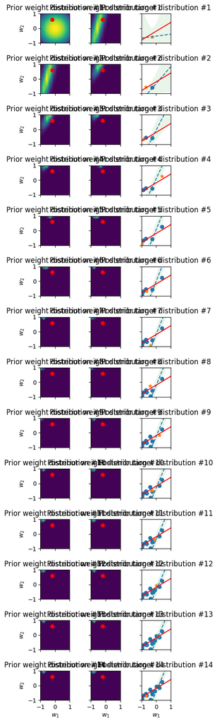

```python
np.random.seed(42)

model = BayesianLinearRegression(n_features=2, alpha=2, beta=25)

N = 100
w = np.linspace(-1, 1, 10)
W = np.dstack(np.meshgrid(w, w))

n_samples = 14
fig = plt.figure(figsize=(7 * n_samples, 21))
grid = ImageGrid(
    fig, 111,
    nrows_ncols=(n_samples, 3),
    axes_pad=.5
)

xs = []
ys = []

def prettify_ax(ax):
    ax.set_xlim(-1, 1)
    ax.set_ylim(-1, 1)
    ax.set_xlabel('$w_1$')
    ax.set_ylabel('$w_2$')
    return ax

for i, (xi, yi) in enumerate(sample(n_samples)):
    pred_dist = model.predict(xi)

    ax = prettify_ax(grid[3 * i])
    ax.set_title(f'Prior weight distribution #{i + 1}')
    ax.contourf(w, w, model.weights_dist.pdf(W), N, cmap='viridis')
    ax.scatter(*weights, color='red')

    model.learn(xi, yi)

    ax = prettify_ax(grid[3 * i + 1])
    ax.set_title(f'Posterior weight distribution #{i + 1}')
    ax.contourf(w, w, model.weights_dist.pdf(W), N, cmap='viridis')
    ax.scatter(*weights, color='red')

    xs.append(xi)
    ys.append(yi)
    posteriors = [model.predict(np.array([1, wi])) for wi in w]
    ax = prettify_ax(grid[3 * i + 2])
    ax.set_title(f'Posterior target distribution #{i + 1}')

    ax.scatter([xi[1] for xi in xs[:-1]], ys[:-1])
    ax.scatter(xs[-1][1], ys[-1], marker='*')

    ax.plot(w, [p.mean() for p in posteriors], linestyle='--')
    cis = [p.interval(.95) for p in posteriors]
    ax.fill_between(
        x=w,
        y1=[ci[0] for ci in cis],
        y2=[ci[1] for ci in cis],
        alpha=.1
    )

    ax.plot(w, [np.dot(weights, [1, xi]) for xi in w], color='red')
```

The obtained results indicate that as more successive points are added, the shape of the posterior distribution becomes increasingly concentrated.